# Bondora Credit Allocation Study

## Study 2 | ERGM | `b1factor("gender")`

- Summary
- Specification
- Results
- MCMC
- GOF

**Modelling Notes**

- Originally, we wanted to test `b1nodematch("gender")`, however this fails to mix
- Gender effect can be indirectly observed with `b1factor("gender")` as well
  - Since this converges without issue, we chose this as a replacement term
- Term change does not impact original hypothesis significantly

**Results**

- Good MCMC + GOF
- Gender term insignificant and with low SE
- AIC/BIC not changed significantly
- $\Rightarrow$ Gender does not impact loan use choice significantly and the model does not significantly improve explanatory power

```r
# Iteration 3 + MCMC Diagnostics + GOF
model_3_params <- bondora_net ~ edges + b1degree(1) + cycle(4) +

  # See if there is gender effect
  b1factor("b1_gender")

model_3 <- ergm::ergm(
  model_3_params,
  #constraints = ~ bd(minout = 0, maxout = 80),

  control = ergm::control.ergm(
    # Greater burn-in for cleaner result
    # Cycles mixed with the rest of the terms requires more burnin samples
    MCMC.burnin = 20000,
    # Greater sample size for greater stability
    MCMC.samplesize = 100000,
    seed = 42,
    # Reducing interval to reduce complexity between intervals
    MCMC.interval = 1000,
    # Only needed for convergence pvals to improve
    MCMLE.maxit = 25,
    # Smaller steps for stability
    MCMLE.steplength = 0.25,
    parallel = n_cores,
    parallel.type = "PSOCK"
  )
)
```

```
===============================================================================
                         Model 1       Model 2       Model 3       Model 4
-------------------------------------------------------------------------------
edges                       -1.98 ***     -1.35 ***     -0.94 ***     -0.86 **
                            (0.05)        (0.12)        (0.28)        (0.29)
b1degree1                                  3.31 ***      3.27 ***      3.26 ***
                                          (0.22)        (0.25)        (0.24)
cycle4                                                  -0.14         -0.14
                                                        (0.09)        (0.09)
b1factor.b1_gender.male                                               -0.18
                                                                      (0.21)
-------------------------------------------------------------------------------
AIC                       3325.83       2674.44       2676.44       2672.01
BIC                       3332.24       2687.26       2695.67       2697.65
Log Likelihood           -1661.91      -1335.22      -1335.22      -1332.01
===============================================================================
*** p < 0.001; ** p < 0.01; * p < 0.05
```

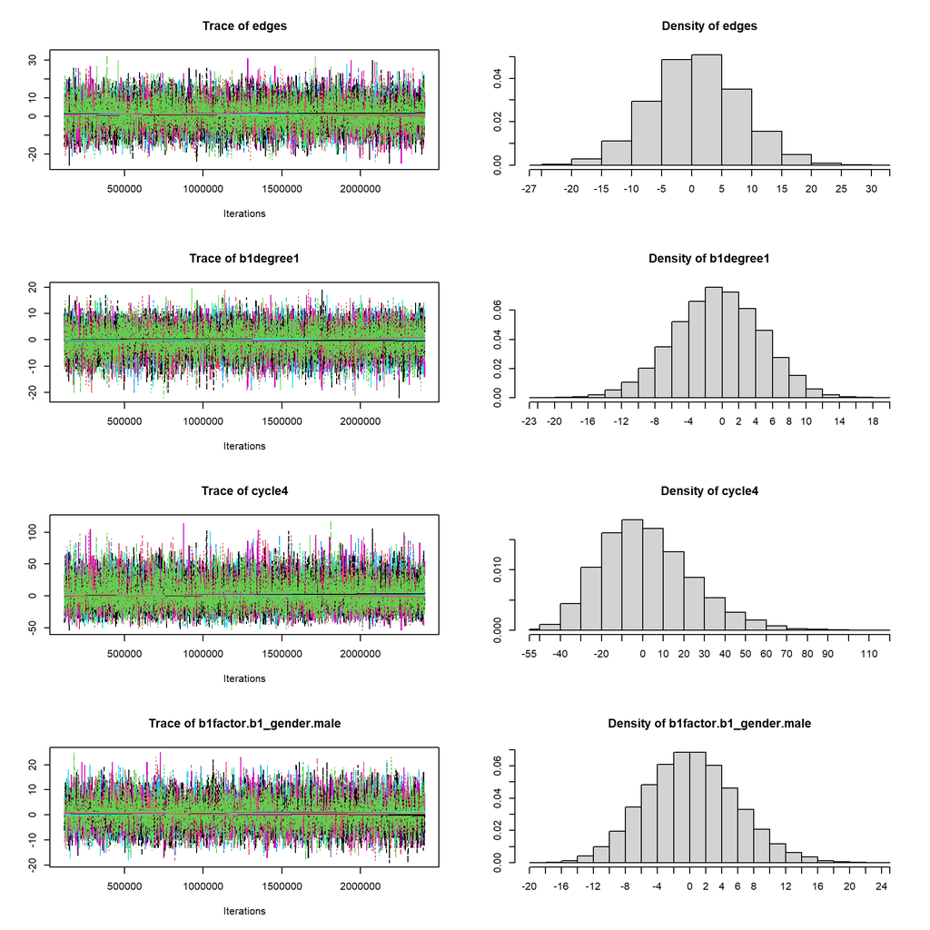

```
Sample statistics summary:

Iterations = 120448:2406528
Thinning interval = 640
Number of chains = 9
Sample size per chain = 3573

1. Empirical mean and standard deviation for each variable,
   plus standard error of the mean:

                            Mean     SD Naive SE Time-series SE
edges                    1.25307  7.431  0.04144        0.06826
b1degree1               -0.05458  5.252  0.02929        0.04472
cycle4                   2.61648 22.356  0.12467        0.18772
b1factor.b1_gender.male  0.71207  5.713  0.03186        0.05854

2. Quantiles for each variable:

                        2.5% 25% 50% 75% 97.5%
edges                    -13  -4   1   6    16
b1degree1                -11  -4   0   4    10
cycle4                   -34 -13   0  16    52
b1factor.b1_gender.male  -10  -3   1   4    12


Are sample statistics significantly different from observed?
                  edges   b1degree1       cycle4 b1factor.b1_gender.male
diff.      1.253071e+00 -0.05457599 2.616475e+00            7.120689e-01
test stat. 1.837232e+01 -1.22226000 1.394755e+01            1.216653e+01
P-val.     2.188414e-75  0.22160932 3.256092e-44            4.685805e-34
                  (Omni)
diff.                 NA
test stat.  4.981756e+02
P-val.     2.180719e-104

Sample statistics cross-correlations:
                             edges  b1degree1     cycle4
edges                    1.0000000 -0.6273622  0.8549354
b1degree1               -0.6273622  1.0000000 -0.5698004
cycle4                   0.8549354 -0.5698004  1.0000000
```

[output cut: 223 more lines]

```
b1factor.b1_gender.male
              0.1536154
Joint P-value (lower = worse):  0.5098452

Note: To save space, only one in every 5 iterations of the MCMC sample
  used for estimation was stored for diagnostics. Sample size per chain
  was originally around 17865 with thinning interval 128.

Note: MCMC diagnostics shown here are from the last round of
  simulation, prior to computation of final parameter estimates.
  Because the final estimates are refinements of those used for this
  simulation run, these diagnostics may understate model performance.
  To directly assess the performance of the final model on in-model
  statistics, please use the GOF command: gof(ergmFitObject,
  GOF=~model).
```

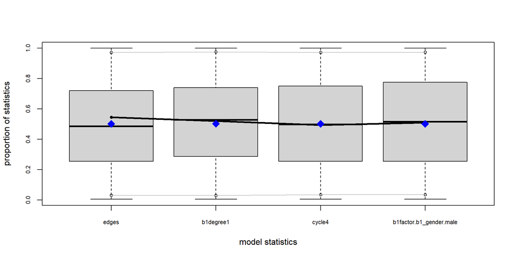

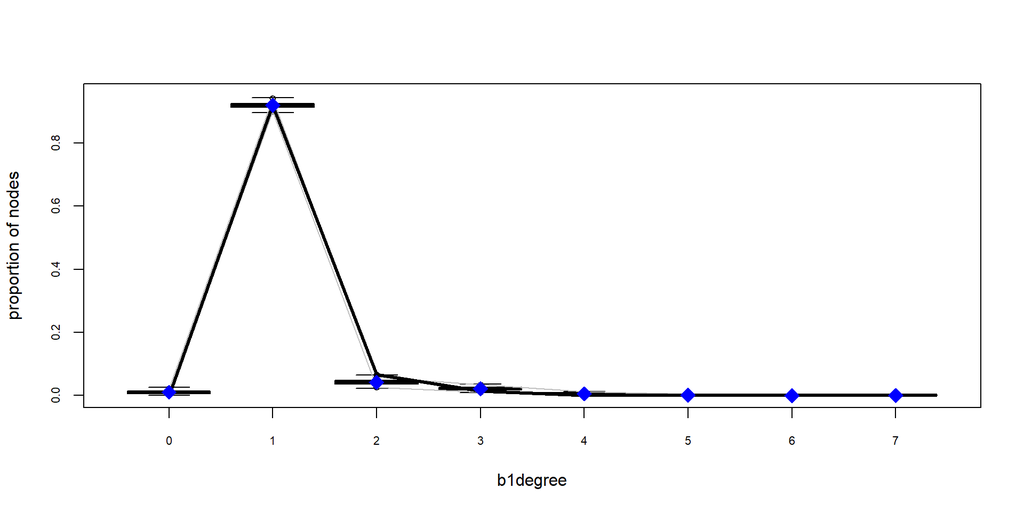

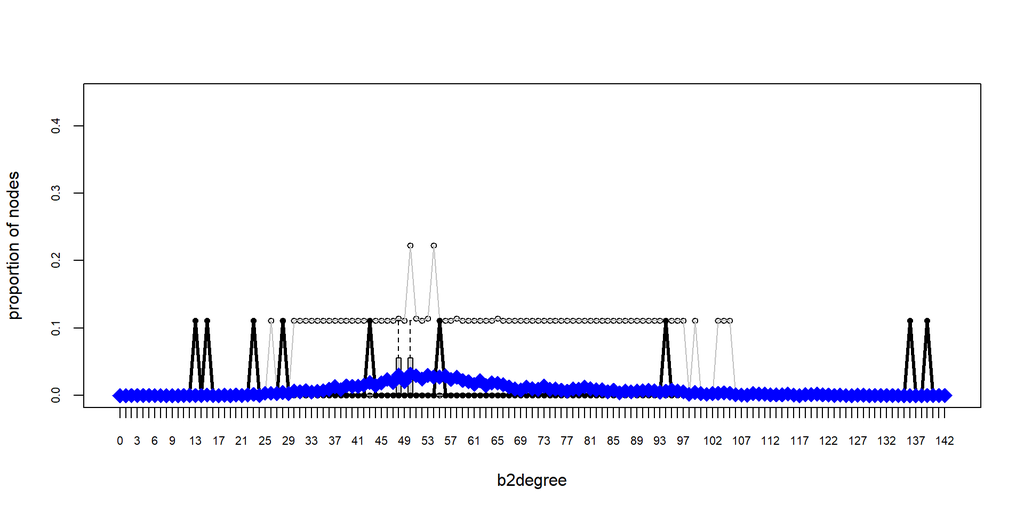

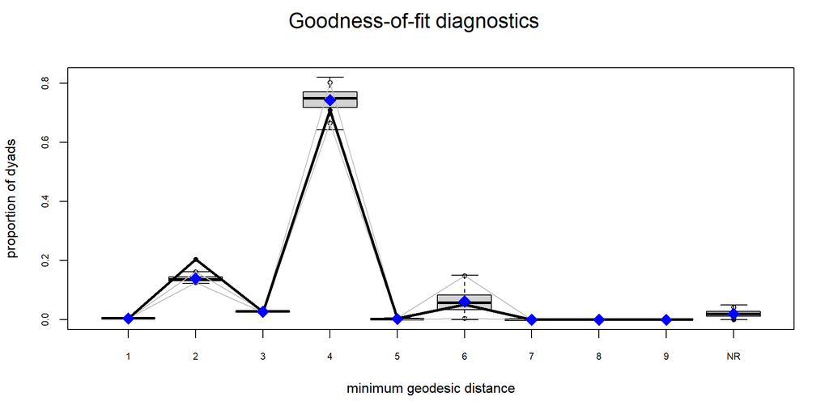

## Study 2 | ERGM | `b1cov("age")`

- Summary
- Specification
- Results
- MCMC
- GOF

**Modelling Notes**

- No issues with convergence

**Results**

- Good MCMC + GOF
- Insignificant term but with low SE
- Increases `edges` term more strongly than model with just `b1factor("gender")`
- $\Rightarrow$ Age is not a significant factor in the formation of loan use mix and its inclusion does not improve model’s explanatory power significantly

```r
# Iteration 4 + MCMC Diagnostics + GOF
model_4_params <- bondora_net ~ edges + b1degree(1) + cycle(4) +
  b1factor("b1_gender") +

  # See if higher ages make a difference
  b1cov("b1_age")

model_4 <- ergm::ergm(
  model_4_params,
  #constraints = ~ bd(minout = 0, maxout = 80),

  control = ergm::control.ergm(
    # Greater burn-in for cleaner result
    MCMC.burnin = 20000,
    # Greater sample size for greater stability
    MCMC.samplesize = 100000,
    seed = 42,
    MCMC.interval = 1000,
    # Only needed for convergence pvals to improve
    MCMLE.maxit = 45,
    # Smaller steps for stability
    MCMLE.steplength = 0.25,
    parallel = n_cores,
    parallel.type = "PSOCK"
  )
)
```

```
=============================================================================================
                         Model 1       Model 2       Model 3       Model 4       Model 5
---------------------------------------------------------------------------------------------
edges                       -1.98 ***     -1.35 ***     -0.94 ***     -0.86 **      -0.54
                            (0.05)        (0.12)        (0.28)        (0.29)        (0.46)
b1degree1                                  3.31 ***      3.27 ***      3.26 ***      3.27 ***
                                          (0.22)        (0.25)        (0.24)        (0.25)
cycle4                                                  -0.14         -0.14         -0.15
                                                        (0.09)        (0.09)        (0.09)
b1factor.b1_gender.male                                               -0.18         -0.17
                                                                      (0.21)        (0.20)
b1cov.b1_age                                                                        -0.01
                                                                                    (0.01)
---------------------------------------------------------------------------------------------
AIC                       3325.83       2674.44       2676.44       2672.01       2674.85
BIC                       3332.24       2687.26       2695.67       2697.65       2706.90
Log Likelihood           -1661.91      -1335.22      -1335.22      -1332.01      -1332.43
=============================================================================================
*** p < 0.001; ** p < 0.01; * p < 0.05
```

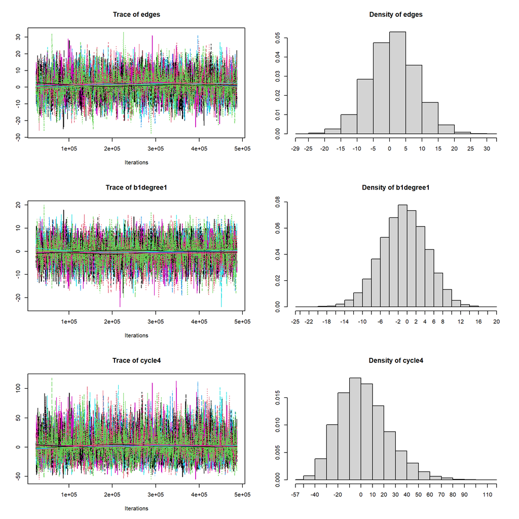

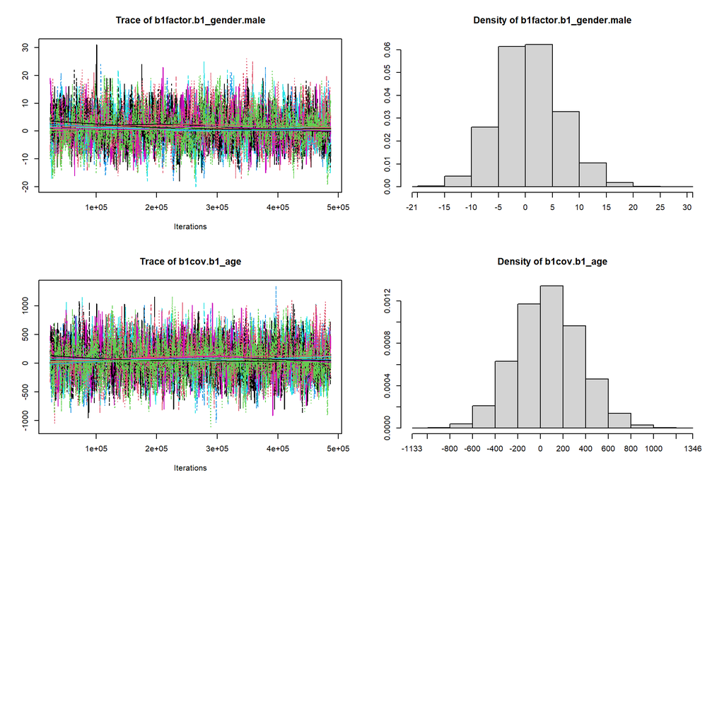

```
Sample statistics summary:

Iterations = 24397:487041
Thinning interval = 124
Number of chains = 9
Sample size per chain = 3732

1. Empirical mean and standard deviation for each variable,
   plus standard error of the mean:

                           Mean      SD Naive SE Time-series SE
edges                    1.4885   7.342  0.04006        0.13991
b1degree1               -0.2421   5.158  0.02815        0.08707
cycle4                   2.9974  21.952  0.11978        0.36758
b1factor.b1_gender.male  1.2371   5.804  0.03167        0.13091
b1cov.b1_age            68.2142 290.100  1.58291        5.53954

2. Quantiles for each variable:

                          2.5%  25% 50% 75% 97.5%
edges                    -13.0   -3   2   6    16
b1degree1                -11.0   -4   0   3     9
cycle4                   -34.0  -13   1  16    52
b1factor.b1_gender.male  -10.0   -3   1   5    13
b1cov.b1_age            -493.3 -128  66 262   642


Are sample statistics significantly different from observed?
                  edges    b1degree1       cycle4 b1factor.b1_gender.male
diff.      1.488508e+00 -0.242080505 2.997410e+00            1.237108e+00
test stat. 1.067485e+01 -2.788939985 8.253381e+00            9.459740e+00
P-val.     1.334799e-26  0.005288086 1.539758e-16            3.087086e-21
           b1cov.b1_age       (Omni)
diff.      6.821421e+01           NA
test stat. 1.234136e+01 1.836478e+02
P-val.     5.423515e-35 1.961837e-36

Sample statistics cross-correlations:
                             edges  b1degree1     cycle4
edges                    1.0000000 -0.6194906  0.8444657
```

[output cut: 227 more lines]

```
b1factor.b1_gender.male            b1cov.b1_age
              0.1167248               0.4266443
Joint P-value (lower = worse):  0.2069806

Note: To save space, only one in every 4 iterations of the MCMC sample
  used for estimation was stored for diagnostics. Sample size per chain
  was originally around 14928 with thinning interval 31.

Note: MCMC diagnostics shown here are from the last round of
  simulation, prior to computation of final parameter estimates.
  Because the final estimates are refinements of those used for this
  simulation run, these diagnostics may understate model performance.
  To directly assess the performance of the final model on in-model
  statistics, please use the GOF command: gof(ergmFitObject,
  GOF=~model).
```

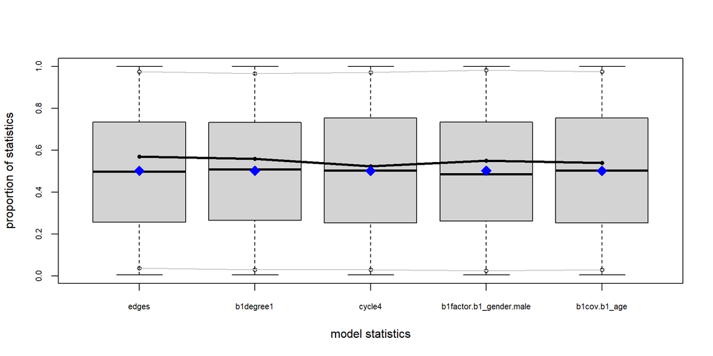

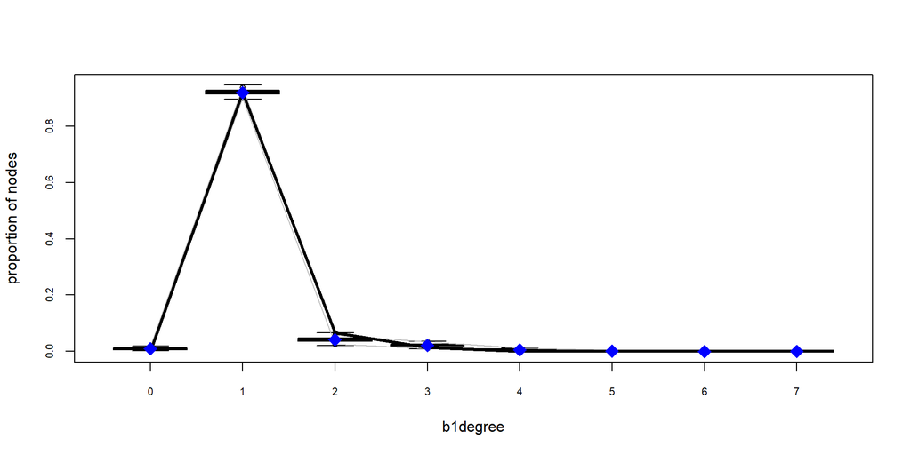

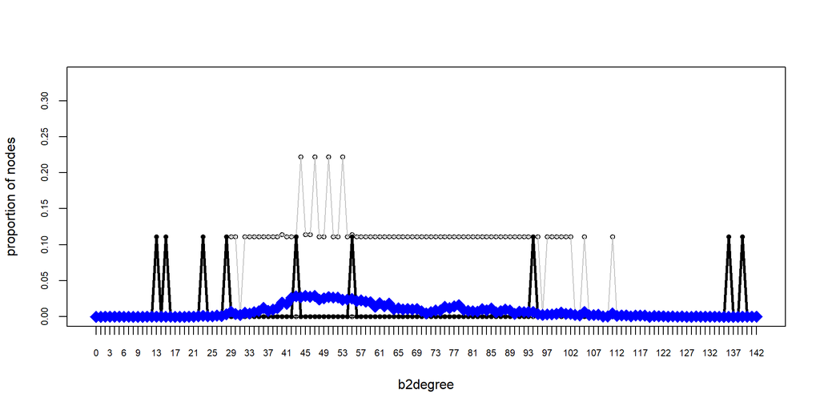

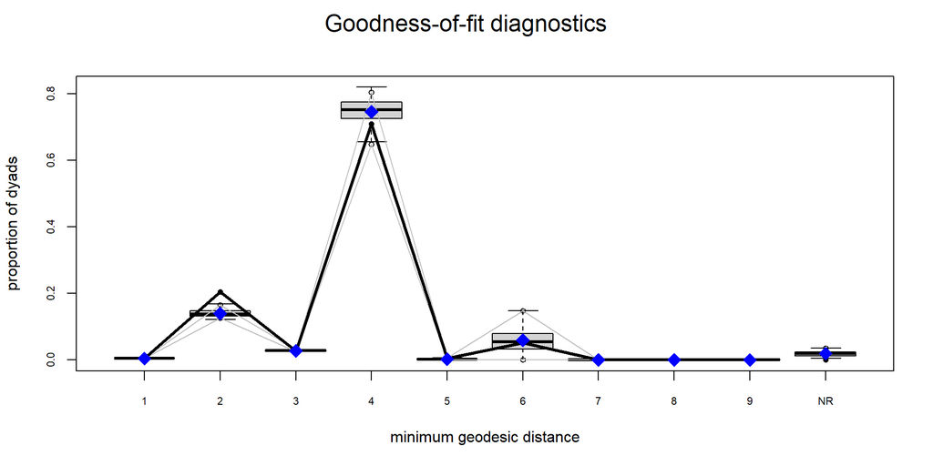

## References

Aggarwal, R. (1981). Exchange rates and stock prices: A study of the u.s. Capital markets under floating exchange rates. *Akron Business and Economic Review*, *12*.

Aliano, M., Alnabulsi, K., Cestari, G., & Ragni, S. (2023). The role of gender and education in peer-to-peer lending activities: Evidence from a european cross-country study. *European Scientific Journal ESJ*, *2*. https://doi.org/10.19044/esipreprint.2.2023.p95

Amar, M., Ariely, D., Ayal, S., Cryder, C. E., & Rick, S. I. (2011). Winning the battle but losing the war: The psychology of debt management. *Journal of Marketing Research*, *48*, S38–S50.

Ayal, S., Bar-Haim, D., & Ofir, M. (2018). Behavioral biases in peer-to-peer (P2P) lending. *Forthcoming in Behavioral Finance: The Coming of Age (Venezia I. Ed., World Scientific Publishers)*.

Ayal, S., & Zakay, D. (2009). The perceived diversity heuristic: The case of pseudodiversity. *Journal of Personality and Social Psychology*, *96*(3), 559–573. https://doi.org/10.1037/a0013906

Cooper, D., Gorbachev, O., & Luengo‐Prado, M. J. (2023). Consumption, credit, and the missing young. *Journal of Money, Credit and Banking*, *55*(2), 379–405.

Croson, R., & Gneezy, U. (2009). Gender differences in preferences. *Journal of Economic Literature*, *47*(2), 448–474.

Galak, J., Small, D. A., & Stephen, A. T. (2010). Micro-finance decision making: A field study of prosocial lending. *SSRN Electronic Journal*. https://doi.org/10.2139/ssrn.1634949

Herzenstein, M., Dholakia, U. M., & Andrews, R. L. (2011). Strategic herding behavior in peer-to-peer loan auctions. *Journal of Interactive Marketing*, *25*(1), 27–36. https://doi.org/10.1016/j.intmar.2010.07.001

Kahneman, D., & Tversky, A. (1979). Prospect theory: An analysis of decision under risk. *Econometrica*, *47*(2), 263–291. https://doi.org/10.2307/1914185

Lee, E., & Lee, B. (2012). Herding behavior in online P2P lending: An empirical investigation. *Electronic Commerce Research and Applications*, *11*(5), 495–503. https://doi.org/10.1016/j.elerap.2012.02.001

Ravina, E. (2019). Love & loans: The effect of beauty and personal characteristics in credit markets. *Available at SSRN 1107307*.

Serrano-Cinca, C., Gutiérrez-Nieto, B., & López-Palacios, L. (2015). Determinants of default in P2P lending. *PLOS ONE*, *10*(10), e0139427. https://doi.org/10.1371/journal.pone.0139427